# Week 2: Homogeneous Transformations

EE0849 Introduction to Robotics

Basri Erdogan

# Part 1: Rotation Composition as a Tool

## Today’s Roadmap

1. Establish rotation-composition rules (current vs fixed frame)
2. Solve the full rigid-motion problem with homogeneous transforms
3. Orientation parameterizations: Euler, RPY, quaternions, and gimbal lock
4. Verify everything in Python with `SE3`

## Rotation Matrix Recap

- $R \in SO(3)$: orthogonal matrix with $\det(R)=+1$
- $R^{-1}=R^T$
- Columns represent rotated frame axes

## Rotation Composition Rules

When combining successive rotations, the multiplication order depends on **which frame** the new rotation is defined in:

- **Current (moving) frame axis** → post-multiply (append on the right):
  $$R_{final} = R_{current} \cdot R_{new}$$
- **Fixed (world) frame axis** → pre-multiply (append on the left):
  $$R_{final} = R_{new} \cdot R_{current}$$

Why? Post-multiplying applies the rotation **in the already-rotated frame**; pre-multiplying applies it **in the original frame**.

## Worked Example: Composing Rotations

**Problem:** Rotate $90^\circ$ about current $z$, then $90^\circ$ about current $x$.

$$R_{final}=R_z(90^\circ)\,R_x(90^\circ)
=\begin{bmatrix}0&-1&0\\1&0&0\\0&0&1\end{bmatrix}
\begin{bmatrix}1&0&0\\0&0&-1\\0&1&0\end{bmatrix}
=\begin{bmatrix}0&0&1\\1&0&0\\0&1&0\end{bmatrix}$$

Two equivalent readings of $R_z(90°)\,R_x(90°)$:

1. **Body frame** (left → right): $z$-rotation, then *current* $x$-rotation
2. **Fixed frame** (right → left): fixed $x$-rotation, then fixed $z$-rotation

Verify $SO(3)$: $R^TR=I$ and $\det(R)=+1$.

## Rotation Composition: Two Paths, Same Result

[interactive chart not shown]

Drag the slider: body-frame (left→right) and fixed-frame (right→left) both reach $R_z(90°)\,R_x(90°)$.

## Conceptual Check + Bridge

If we reverse the order, do we get the same result?

No — rotation is **not commutative**: $R_x R_z \neq R_z R_x$.

Rotations change orientation, but rigid bodies also translate:
$$p^0 = R_1^0 p^1 + d_1^0$$

Next: convert this affine form into a single matrix multiplication.

# Part 2: Homogeneous Transformations

## The Rigid-Motion Problem

A rigid body in space has both orientation and position:
$$p^0 = R_1^0 p^1 + d_1^0$$

This affine map mixes a matrix product and a vector addition — it is **not** a single linear operation in 3D coordinates.

[figure not shown]

## The Homogeneous Matrix

Lift to 4D so rigid motion becomes linear:

$$H_1^0 = \begin{bmatrix}R_1^0 & d_1^0 \\ 0_{1\times3} & 1\end{bmatrix} \in SE(3)$$

Point form:
$$P = \begin{bmatrix}x\\y\\z\\1\end{bmatrix}$$

## Homogeneous Operation

Now one multiplication handles both rotation and translation:

$$P^0 = H_1^0 P^1$$

$$\begin{bmatrix}p^0\\1\end{bmatrix}
=
\begin{bmatrix}R_1^0&d_1^0\\0&1\end{bmatrix}
\begin{bmatrix}p^1\\1\end{bmatrix}$$

This expands back to $p^0 = R_1^0 p^1 + d_1^0$.

## Worked Example: Build $H$

Frame $\{1\}$ is rotated $90^\circ$ about $z$ and translated by $[1,2,0]^T$ from frame $\{0\}$.

$$H_1^0=
\begin{bmatrix}
\color{#c0392b}{0}&\color{#c0392b}{-1}&\color{#c0392b}{0}&\color{#2471a3}{1}\\
\color{#c0392b}{1}&\color{#c0392b}{0}&\color{#c0392b}{0}&\color{#2471a3}{2}\\
\color{#c0392b}{0}&\color{#c0392b}{0}&\color{#c0392b}{1}&\color{#2471a3}{0}\\
0&0&0&1
\end{bmatrix}$$

$\color{#c0392b}{R_z(90°)}$ | $\color{#2471a3}{d}$

[figure not shown]

## Worked Example: Transform a Point

Using $H_1^0$ from the previous slide, transform $p^1=[1,\,0.5,\,0]^T$:

$$\begin{bmatrix}p^0\\1\end{bmatrix}
=
\begin{bmatrix}0&-1&0&1\\1&0&0&2\\0&0&1&0\\0&0&0&1\end{bmatrix}
\begin{bmatrix}1\\0.5\\0\\1\end{bmatrix}
=
\begin{bmatrix}0.5\\3\\0\\1\end{bmatrix}$$

So $p^0=[0.5,\,3,\,0]^T$.

[figure not shown]

## Transform Notation and Chain Rule

$$H_B^A: \text{transform from frame }\{B\}\text{ to frame }\{A\}$$

Composition:
$$H_2^0 = H_1^0 H_2^1$$

Read right-to-left: from 2 to 1, then 1 to 0.

## Composition of Homogeneous Transforms

- Same composition logic as rotations
- Associative: $(H_1H_2)H_3 = H_1(H_2H_3)$
- Not commutative: $H_1H_2 \neq H_2H_1$

[figure not shown]

## Inverse of $H$

- Do **not** use transpose: $H^{-1} \neq H^T$
- Correct inverse:

$$H^{-1}=\begin{bmatrix}R^T & -R^T d \\ 0 & 1\end{bmatrix}$$

Geometric intuition: rotate back, then translate back in rotated coordinates.

## Why $H^T$ Fails as an Inverse

Why can’t we just transpose $H$ like we do for $R$?

$$H^T=\begin{bmatrix}R^T&0\\d^T&1\end{bmatrix}$$

The bottom row becomes $[d^T\;\; 1]$ — this breaks homogeneous-transform structure (which requires $[0\;\;0\;\;0\;\;1]$).

## Worked Example: Compute $H^{-1}$

Given $H=\begin{bmatrix}0&-1&0&1\\1&0&0&2\\0&0&1&0\\0&0&0&1\end{bmatrix}$, extract $R=\begin{bmatrix}0&-1&0\\1&0&0\\0&0&1\end{bmatrix}$, $d=\begin{bmatrix}1\\2\\0\end{bmatrix}$

$$R^T=\begin{bmatrix}0&1&0\\-1&0&0\\0&0&1\end{bmatrix},\quad
-R^Td=-\begin{bmatrix}2\\-1\\0\end{bmatrix}=\begin{bmatrix}-2\\1\\0\end{bmatrix}$$

$$H^{-1}=\begin{bmatrix}0&1&0&-2\\-1&0&0&1\\0&0&1&0\\0&0&0&1\end{bmatrix}$$

Check: $H\,H^{-1}=I$ ✓

## Practice: Frame Chain

Frame $\{1\}$: translated by $[2,0,0]^T$ from $\{0\}$. Frame $\{2\}$: rotated $90^\circ$ about $z$ from $\{1\}$.

1. Find $H_1^0$ and $H_2^1$
2. Compute $H_2^0$
3. Find origin of $\{2\}$ in frame $\{0\}$

$$H_1^0=\begin{bmatrix}1&0&0&2\\0&1&0&0\\0&0&1&0\\0&0&0&1\end{bmatrix},\quad
H_2^1=\begin{bmatrix}0&-1&0&0\\1&0&0&0\\0&0&1&0\\0&0&0&1\end{bmatrix}$$

$$H_2^0=H_1^0H_2^1=\begin{bmatrix}0&-1&0&2\\1&0&0&0\\0&0&1&0\\0&0&0&1\end{bmatrix}$$

Origin of $\{2\}$ in $\{0\}$: $[2,0,0]^T$.

## Practice: Inverse of Pure Translation

Compute $H^{-1}$ for
$$H=\begin{bmatrix}1&0&0&3\\0&1&0&4\\0&0&1&5\\0&0&0&1\end{bmatrix}$$

Hint: identify $R$ and $d$ first.

Since $R=I$: $R^T=I$, $-R^Td=-d$

$$H^{-1}=\begin{bmatrix}1&0&0&-3\\0&1&0&-4\\0&0&1&-5\\0&0&0&1\end{bmatrix}$$

For pure translations, just negate the translation vector.

## Practice: Bolt Grasp Problem

A manipulator must pick up a bolt from a table. Four frames:

- $\{B\}$: manipulator base, $\;\{T\}$: tool (end-effector)
- $\{S\}$: table surface, $\;\{G\}$: grasp point (bolt)

**Known:** $H_T^B$, $\;H_S^B$, $\;H_G^S$

**Find:** $H_G^T$ — the bolt’s pose in the tool frame.

Chain: $\{G\}\xrightarrow{H_G^S}\{S\}\xrightarrow{H_S^B}\{B\}\xrightarrow{(H_T^B)^{-1}}\{T\}$

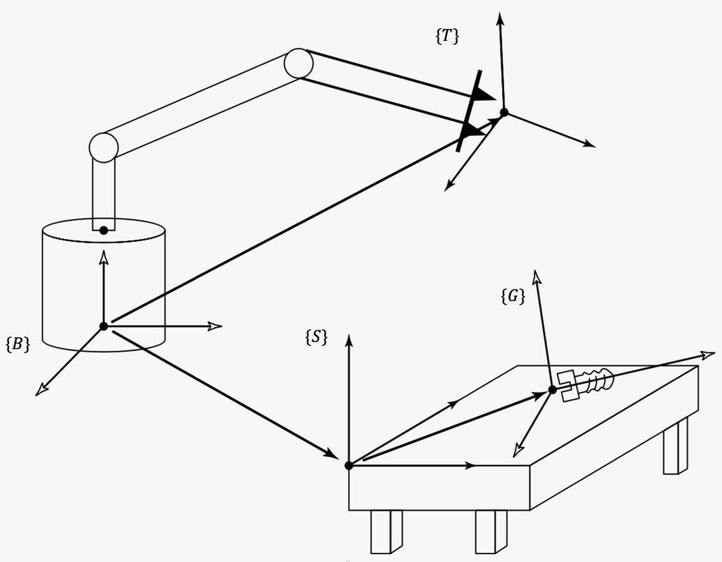

$$H_G^T = (H_T^B)^{-1}\, H_S^B\, H_G^S$$

The inverse $(H_T^B)^{-1}$ “undoes” the base→tool transform, bridging through $\{B\}$.

# Part 3: Orientation Parameterization

## What Is Orientation Parameterization?

In $H = \begin{bmatrix}R & d\\0 & 1\end{bmatrix}$, orientation lives in $R$.

$R$ has 9 entries but 6 orthogonality constraints — only **3 DOF**.

**Parameterization** = describe $R$ with a minimal set of independent numbers (typically 3 angles) plus a convention (which axes, which order). The angles fully determine $R$.

## Why Parameterize?

Why not just use $R$ directly?

- **Interpretability:** “Roll 30°, pitch 15°, yaw 45°” is intuitive — a 3×3 matrix of decimals is not. Every robot teach pendant shows angles, not matrices.
- **Control:** A controller should track 3 error signals for 3 DOF — not 9 coupled entries with 6 hidden constraints.
- **Interpolation:** You cannot linearly interpolate two $R$ matrices (it breaks orthogonality). Angle-based and quaternion representations make smooth trajectories possible.

## Euler Angles (Z-Y-Z)

Sequence of rotations about **current (body) frame** axes:

1. Rotate about $z$ by $\phi$
2. Rotate about current $y'$ by $\theta$
3. Rotate about current $z''$ by $\psi$

$$R_{ZYZ} = R_{z,\phi}\,R_{y,\theta}\,R_{z,\psi}$$

Note: the first and last axes are the **same** ($z$) — this is a defining feature of Euler-type sequences.

## Z-Y-Z: Expanded Matrix

Using shorthand $c_\phi=\cos\phi$, $s_\phi=\sin\phi$, etc.:

$$R_{ZYZ}=\begin{bmatrix}c_\phi c_\theta c_\psi - s_\phi s_\psi & -c_\phi c_\theta s_\psi - s_\phi c_\psi & c_\phi s_\theta \\
s_\phi c_\theta c_\psi + c_\phi s_\psi & -s_\phi c_\theta s_\psi + c_\phi c_\psi & s_\phi s_\theta \\
-s_\theta c_\psi & s_\theta s_\psi & c_\theta
\end{bmatrix}$$

## Extracting Euler Angles from $R$

Given $R = [r_{ij}]$, extract $(\phi, \theta, \psi)$ when $\sin\theta \neq 0$:

$$\theta = \text{atan2}\!\left(\sqrt{r_{13}^2+r_{23}^2},\; r_{33}\right)$$

$$\phi = \text{atan2}(r_{23},\; r_{13})$$

$$\psi = \text{atan2}(r_{32},\; -r_{31})$$

When $\sin\theta = 0$ → **gimbal lock**: only $\phi \pm \psi$ is determined.

## Worked Example: Euler Extraction

Extract Z-Y-Z angles from:
$$R = \begin{bmatrix} 0 & 0 & 1 \\ 0 & 1 & 0 \\ -1 & 0 & 0 \end{bmatrix}$$

$r_{33} = 0 \;\Rightarrow\; \theta = \text{atan2}\!\left(\sqrt{1^2+0^2},\;0\right) = 90°$

$\phi = \text{atan2}(r_{23},\,r_{13}) = \text{atan2}(0,\,1) = 0°$

$\psi = \text{atan2}(r_{32},\,-r_{31}) = \text{atan2}(0,\,1) = 0°$

**Answer:** $\phi=0°,\; \theta=90°,\; \psi=0°$

## Gimbal Lock

**When:** $\sin\theta=0$ ($\theta=0°$ or $180°$)

The first and third rotation axes align — two sliders now rotate about the **same axis**.

**What goes wrong:**

- Cannot recover unique $\phi$, $\psi$ from $R$ — only their sum $\phi+\psi$
- $\phi$ and $\psi$ both rotate about $z$ — two knobs, one effect

[interactive chart not shown]

## Worked Example: Gimbal Lock

Extract Z-Y-Z angles from $R_z(90°)$:
$$R = \begin{bmatrix} 0 & -1 & 0 \\ 1 & 0 & 0 \\ 0 & 0 & 1 \end{bmatrix}$$

$r_{33}=1 \;\Rightarrow\; \theta = 0°$ → **Gimbal lock!**

The first and third rotation axes are aligned, so only $\phi+\psi$ is determined:
$$\phi + \psi = \text{atan2}(r_{21},\, r_{11}) = \text{atan2}(1,\, 0) = 90°$$

Convention: set $\psi=0°$, giving $\phi=90°$.

## Roll-Pitch-Yaw (R-P-Y)

Rotations about **fixed (world) frame** axes:

$$R_{RPY} = R_z(\psi)\,R_y(\theta)\,R_x(\phi)$$

- $\phi$: roll (about $x$)
- $\theta$: pitch (about $y$)
- $\psi$: yaw (about $z$)

ROS convention: $x$ forward, $y$ left, $z$ up.

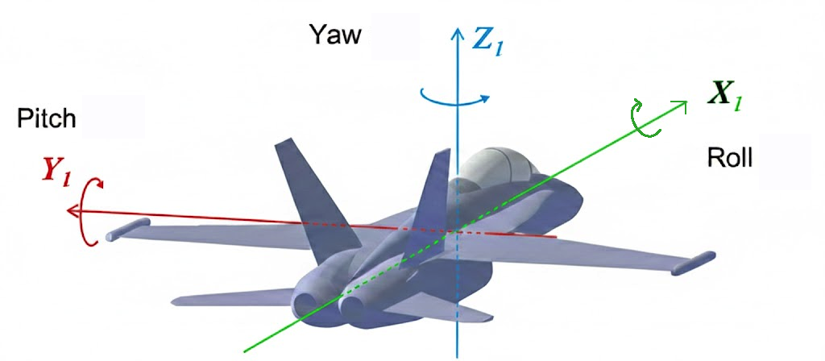

## RPY: Extraction from $R$

Given $R = [r_{ij}]$:

$$\theta = \text{atan2}\!\left(-r_{31},\;\sqrt{r_{11}^2+r_{21}^2}\right) \quad \text{(pitch)}$$

$$\phi = \text{atan2}(r_{32},\; r_{33}) \quad \text{(roll)}$$

$$\psi = \text{atan2}(r_{21},\; r_{11}) \quad \text{(yaw)}$$

**Gimbal lock** when $\cos\theta = 0$ (i.e., $\theta = \pm 90°$) — pitch straight up/down.

## Conceptual Check: Euler vs RPY

Both use 3 angles — what’s the difference?

- **Euler angles (Z-Y-Z):** rotations about the **current (moving) frame** axes — may reuse an axis
- **Roll-Pitch-Yaw:** rotations about the **fixed (world) frame** axes — all different ($x$, $y$, $z$)

Same underlying principle: decompose $R$ into three elemental rotations. The choice of axes and frame convention differs.

Both suffer from gimbal lock, but at **different** configurations.

## Unit Quaternions

A quaternion encodes rotation as a **4-element unit vector**:

$$\mathbf{q} = \cos\tfrac{\theta}{2} + \sin\tfrac{\theta}{2}\,(k_x\,\mathbf{i} + k_y\,\mathbf{j} + k_z\,\mathbf{k})$$

often written as $\mathbf{q} = (w,\, x,\, y,\, z)$ with $\|\mathbf{q}\|=1$.

- **No singularities** — the only representation that avoids gimbal lock entirely
- Compact (4 numbers vs. 9 for a matrix)
- **SLERP** (Spherical Linear Interpolation) gives smooth, constant-speed rotation blending

## Why Quaternions Matter in Practice

**Where you’ll see them:**

- `spatialmath.UnitQuaternion` in Python
- ROS `geometry_msgs/Quaternion`
- FANUC internal orientation storage
- Game engines (Unity, Unreal)

**SLERP preview (Week 6):**

Interpolate smoothly between orientations $\mathbf{q}_0$ and $\mathbf{q}_1$:

$$\text{slerp}(\mathbf{q}_0, \mathbf{q}_1, t) = \mathbf{q}_0\,(\mathbf{q}_0^{-1}\mathbf{q}_1)^t$$

No gimbal lock, constant angular velocity — ideal for trajectory generation.

## Parameterization Comparison

| Parameterization | Params | Singularity | Common Use |
| --- | --- | --- | --- |
| Euler (Z-Y-Z) | 3 | $\theta = 0, \pi$ | Wrist joints, crystallography |
| Roll-Pitch-Yaw | 3 | $\theta = \pm 90°$ | Aerospace, mobile robots, ROS |
| Quaternion | 4 | None | Interpolation, trajectory, controls |

**No 3-parameter representation is globally singularity-free** (topological fact).

Quaternions trade one extra parameter + unit constraint for global coverage and smooth interpolation.

# Part 4: Python Verification

## Python: `spatialmath` Basics

```python
from spatialmath import SE3, SO3
import numpy as np

# Rotation
R = SO3.Rz(90, 'deg')
print(R)

# Homogeneous transform
T = SE3.Rt(R, [1, 2, 0])
print(T)
```

[figure not shown]

## Python: Composition and Inverse

```python
# Composition
T1 = SE3.Tx(2)
T2 = SE3.Rz(90, 'deg')
T_total = T1 * T2
print(T_total)

# Inverse + verification
T_inv = T1.inv()
print(T_inv)
print(T1 * T_inv)  # Identity
```

[figure not shown]

## Python: Transform a Point + Visualization

```python
# Transform a point
T = SE3.Rz(90, 'deg') * SE3.Tx(1)
p1 = np.array([1, 0, 0])
p0 = T * p1
print(f"p0 = {p0}")

# Visualize frame chains
T0 = SE3()
T1 = SE3.Tz(1) * SE3.Rx(45, 'deg')
T2 = T1 * SE3.Ty(0.5) * SE3.Rz(30, 'deg')
ax = T0.plot(frame='0', color='black')
T1.plot(ax=ax, frame='1', color='red')
T2.plot(ax=ax, frame='2', color='blue')
```

[figure not shown]

# Part 5: Summary and Exit Ticket

## Key Takeaways

1. Rotation composition order depends on frame definition
2. Rigid motion is naturally modeled with homogeneous transforms in $SE(3)$
3. Core chain rule: $H_2^0 = H_1^0 H_2^1$
4. Inverse rule: $H^{-1}=\begin{bmatrix}R^T & -R^T d\\0&1\end{bmatrix}$
5. Euler-style parameterizations are compact but can be singular

## Exit Ticket

Given
$$H_1^0 = \begin{bmatrix}1&0&0&1\\0&1&0&0\\0&0&1&0\\0&0&0&1\end{bmatrix},\quad
H_2^1 = \begin{bmatrix}0&-1&0&0\\1&0&0&1\\0&0&1&0\\0&0&0&1\end{bmatrix}$$

Find $H_2^0$.

$$H_2^0 = H_1^0 H_2^1 = \begin{bmatrix}0&-1&0&1\\1&0&0&1\\0&0&1&0\\0&0&0&1\end{bmatrix}$$

Origin of $\{2\}$ in $\{0\}$ is $[1,1,0]^T$.

## What’s Next

**Reading:** Spong, Chapter 2.3–2.5 (Homogeneous Transformations)

**Lab:** Build a transform calculator with `SE3` — compose and invert frame transforms, visualize moving objects, verify hand calculations

**Next week:** Forward kinematics and the Denavit–Hartenberg convention

Contact: b.erdogan@iku.edu.tr